# GAMs with daylength

Philippine Chambault

2023-06-27

- Context: obtained different results with the GAMs late June when checking the code, especially some gaps in the predicted values for depth between 110 and 144 m.
- Objective: investigate why such weird residuals.
- changes made compared to previous version (before June 2023):
- retained only months from Jun to Dec for LR dataset
- removed from HR dataset id 27262 that was tracked for less than 1 month
- recalculated mean_dep for HR dataset: previously was mean(mean_dep) instead of mean(max_dep)
- obtained higher deviance but weird residuals

```
## # A tibble: 19 × 5
##    id     start      end        duration ndives
##    <chr>  <date>     <date>     <drtn>    <int>
##  1 22849  2013-09-27 2013-10-13  16 days      4
##  2 22849b 2014-07-22 2014-12-11 142 days     91
##  3 22850  2013-10-03 2013-12-10  68 days     28
##  4 22850b 2014-07-17 2014-11-28 134 days    115
##  5 22853  2013-09-25 2013-10-21  26 days     15
##  6 22854  2014-07-22 2014-12-03 134 days    114
##  7 27261  2013-10-02 2013-11-30  59 days     15
##  8 27261b 2014-07-16 2014-11-18 125 days    123
##  9 27262  2013-10-04 2013-10-16  12 days      4
## 10 27262b 2014-07-22 2014-12-01 132 days    102
## 11 37227  2013-10-02 2013-11-14  43 days     14
## 12 37228  2013-10-02 2013-12-02  61 days     14
## 13 37235  2013-10-01 2013-11-12  42 days      6
## 14 37235b 2014-07-16 2014-11-27 134 days    113
## 15 7617   2012-07-26 2013-10-27 458 days    266
## 16 7618   2012-07-26 2013-09-13 414 days    189
## 17 93096  2014-07-16 2014-11-22 129 days    103
## 18 93100  2014-07-22 2014-11-04 105 days     78
## 19 93102  2014-07-16 2014-12-11 148 days    128
```

```
## # A tibble: 4 × 5
##   id     start      end        duration ndives
##   <chr>  <date>     <date>     <drtn>    <int>
## 1 22849b 2014-07-22 2014-12-15 146 days    147
## 2 22850b 2014-07-17 2014-12-03 139 days    140
## 3 27262b 2014-07-22 2014-12-07 138 days    139
## 4 93100  2014-07-27 2014-12-31 157 days    158
```

```
## [1] 10
```

# 1 Depth vs daylength from raw data

## 1.1 mean_dep

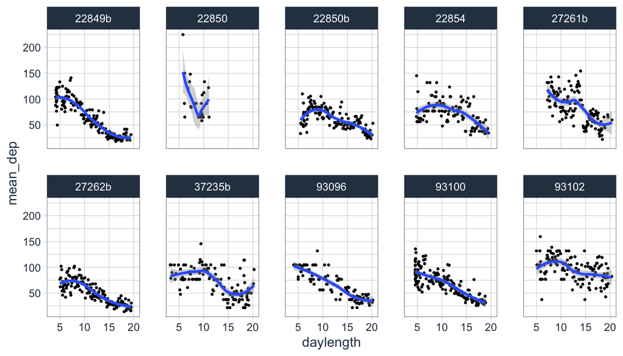

Figure 1.1: Relationship between daily mean depth (from max_dep/dive) and daylengtn.

## 1.2 max_dep

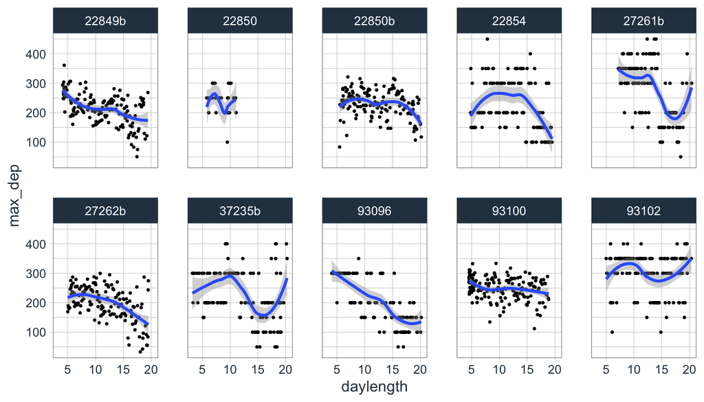

Figure 1.2: Relationship between daily max depth and daylengtn.

# 2 Pairwise colinearity

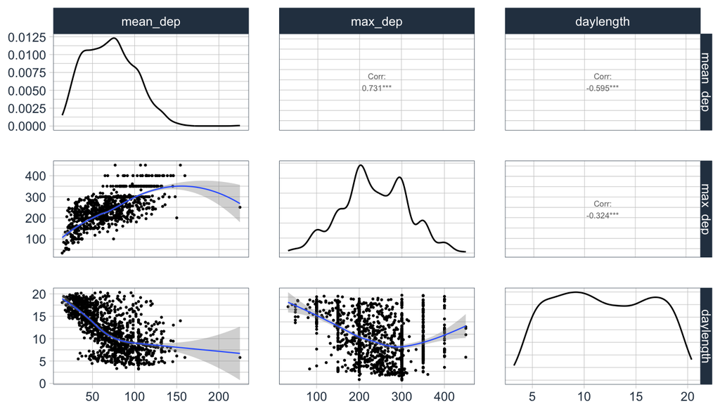

Figure 2.1: Pairwise correlations between variables.

# 3 Simple GAM with mean_dep

## 3.1 Output

- Good deviance even though slightly lower than before.

```
##
## Family: gaussian
## Link function: identity
##
## Formula:
## mean_dep ~ s(daylength, k = 5) + s(id, bs = "re") + s(daylength,
##     id, bs = "re")
##
## Parametric coefficients:
##             Estimate Std. Error t value Pr(>|t|)
## (Intercept)   70.955      7.869   9.017   <2e-16 ***
## ---
## Signif. codes:  0 '***' 0.001 '**' 0.01 '*' 0.05 '.' 0.1 ' ' 1
##
## Approximate significance of smooth terms:
##                   edf Ref.df       F p-value
## s(daylength)    3.669  3.934   31.39  <2e-16 ***
## s(id)           8.198  9.000 8411.73  <2e-16 ***
## s(daylength,id) 8.073  9.000 7194.63  <2e-16 ***
## ---
## Signif. codes:  0 '***' 0.001 '**' 0.01 '*' 0.05 '.' 0.1 ' ' 1
##
## R-sq.(adj) =   0.62   Deviance explained = 62.6%
## -REML = 5181.5  Scale est. = 326.64    n = 1193
```

## 3.2 Smooth curves

- Good fit

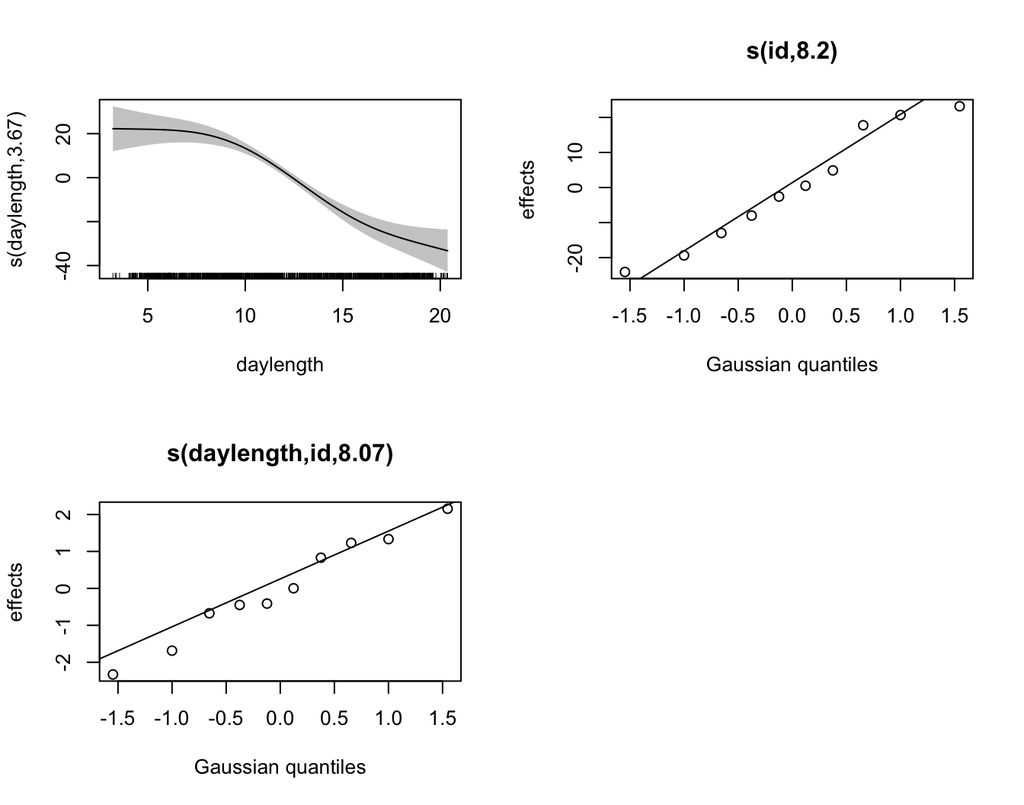

  Figure 3.1: GAM output using mean_dep, ID on slope and intercept.

## 3.3 Residuals

- Good fit.

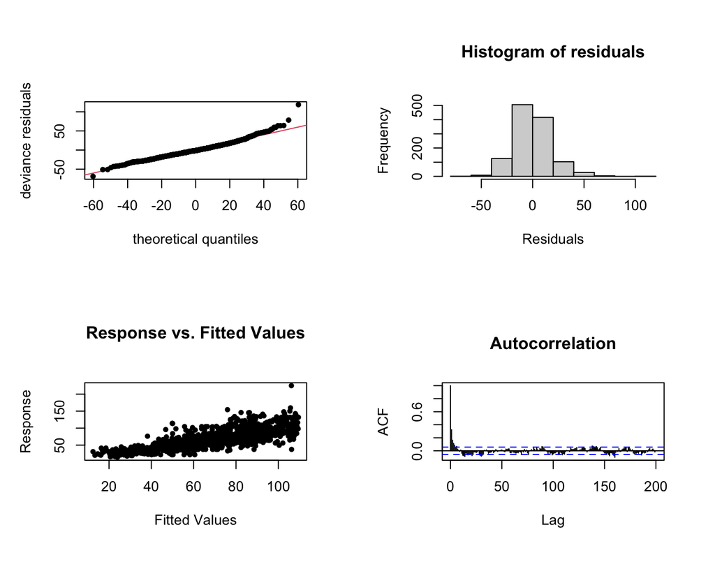

  Figure 3.2: Diagnostic plots using mean_dep.

## 3.4 Individual and population curves

- Similar curve as before

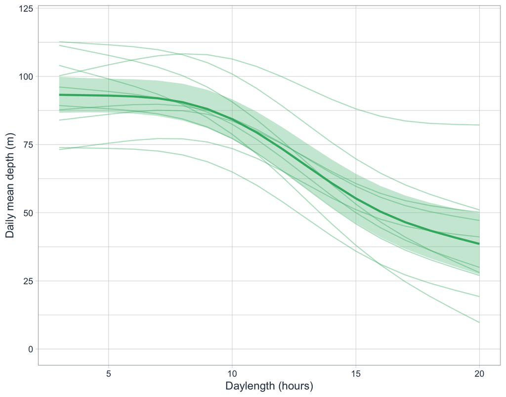

  Figure 3.3: Individual and population smooth curves using daily mean_dep.

# 4 Simple GAM with max_dep

## 4.1 Output

- Ok deviance.

```
##
## Family: gaussian
## Link function: identity
##
## Formula:
## max_dep ~ s(daylength, k = 5) + s(id, bs = "re") + s(daylength,
##     id, bs = "re")
##
## Parametric coefficients:
##             Estimate Std. Error t value Pr(>|t|)
## (Intercept)    234.7       20.9   11.23   <2e-16 ***
## ---
## Signif. codes:  0 '***' 0.001 '**' 0.01 '*' 0.05 '.' 0.1 ' ' 1
##
## Approximate significance of smooth terms:
##                   edf Ref.df       F p-value
## s(daylength)    3.761  3.964   14.77  <2e-16 ***
## s(id)           7.993  9.000 3986.17  <2e-16 ***
## s(daylength,id) 7.691  9.000 3627.80  <2e-16 ***
## ---
## Signif. codes:  0 '***' 0.001 '**' 0.01 '*' 0.05 '.' 0.1 ' ' 1
##
## R-sq.(adj) =   0.36   Deviance explained = 37.1%
## -REML = 6627.5  Scale est. = 3724.3    n = 1193
```

## 4.2 Smooth curves

- Ok fit for the random intercept, except for 2 IDs.
- Better fit with meandep.

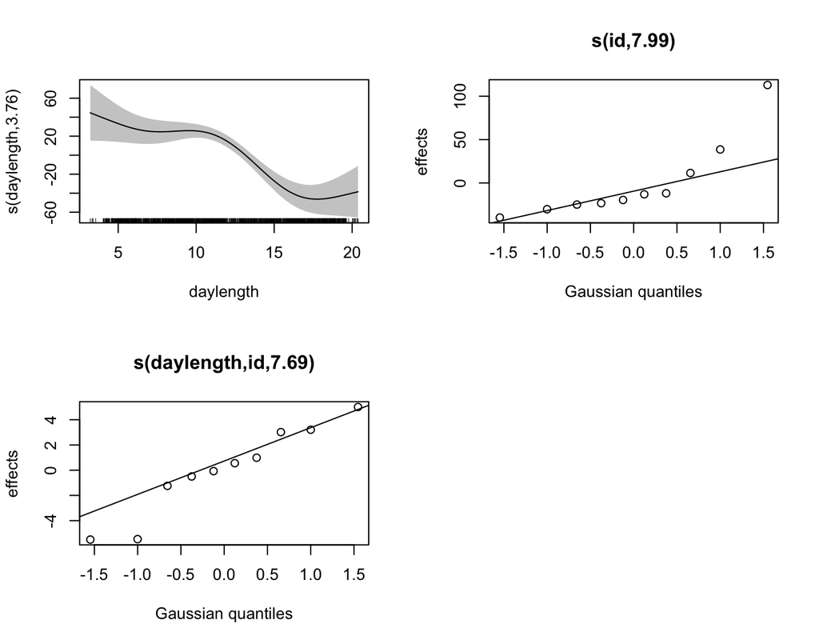

  Figure 4.1: GAM output using max_dep, ID on slope and intercept.

## 4.3 Residuals

- Ok residuals

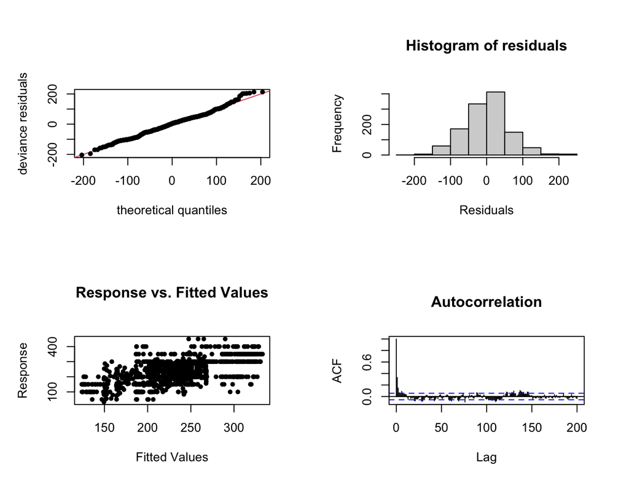

  Figure 4.2: Diagnostic plots using max_dep.

## 4.4 Individual and population curves

- Ok trend but slope less pronounced than the one using mean depth.

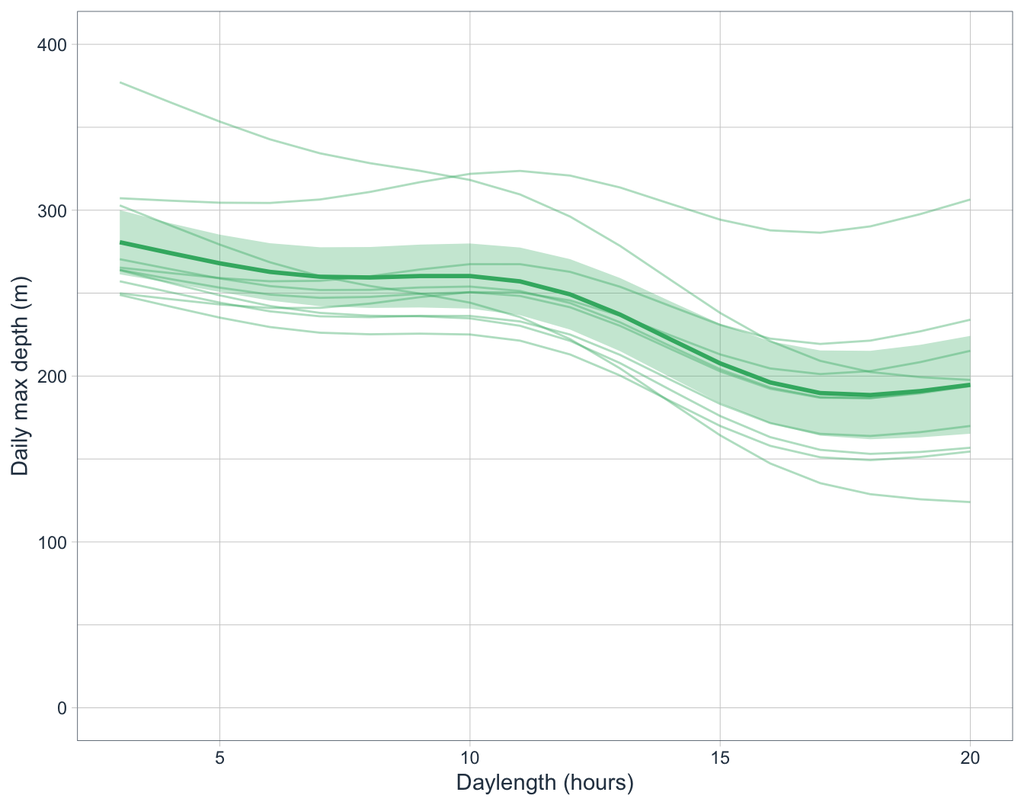

  Figure 4.3: Individual and population smooth curves using daily max_dep.

# 5 Simple GAM with mean of mean_dep

## 5.1 Output

- Higher deviance than the one using mean of maxdep.

```
##
## Family: gaussian
## Link function: identity
##
## Formula:
## mean_dep ~ s(daylength, k = 5) + s(id, bs = "re") + s(daylength,
##     id, bs = "re")
##
## Parametric coefficients:
##             Estimate Std. Error t value Pr(>|t|)
## (Intercept)    62.66      10.99   5.703 1.49e-08 ***
## ---
## Signif. codes:  0 '***' 0.001 '**' 0.01 '*' 0.05 '.' 0.1 ' ' 1
##
## Approximate significance of smooth terms:
##                   edf Ref.df        F p-value
## s(daylength)    3.618  3.913    25.75  <2e-16 ***
## s(id)           8.749  9.000 36901.42  <2e-16 ***
## s(daylength,id) 8.015  9.000 22171.22  <2e-16 ***
## ---
## Signif. codes:  0 '***' 0.001 '**' 0.01 '*' 0.05 '.' 0.1 ' ' 1
##
## R-sq.(adj) =   0.72   Deviance explained = 72.5%
## -REML = 5067.2  Scale est. = 266.97    n = 1193
```

## 5.2 Smooth curves

- Good fit

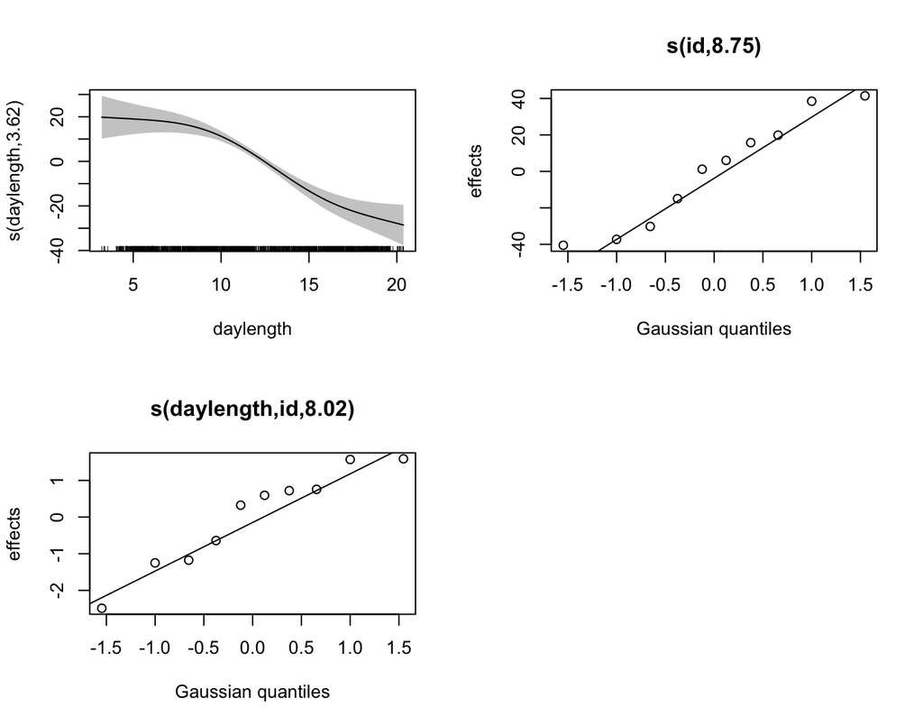

  Figure 5.1: GAM output using mean of mean_dep, ID on slope and intercept.

## 5.3 Residuals

- Good fit

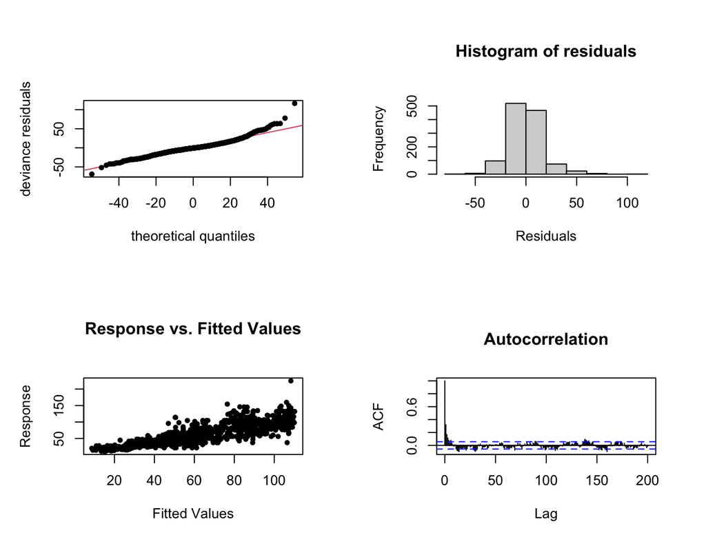

  Figure 5.2: Diagnostic plots using mean of mean_dep.

## 5.4 Individual and population curves

- Ok trend but slope less pronounced than the one using mean depth.

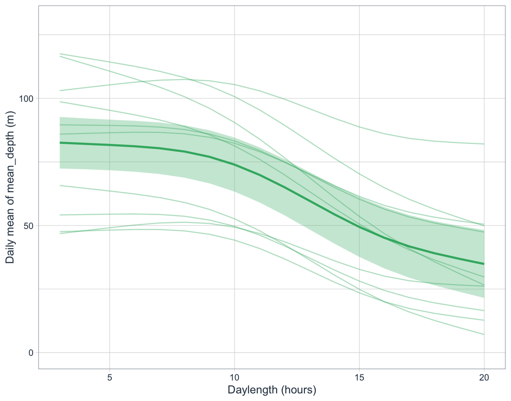

  Figure 5.3: Individual and population smooth curves using daily mean of mean_dep.